# Lab 1: Gapminder Data Visualization

Author

Nirbhay Singh Naruka

Published

October 4, 2023

**Task 1**

Below is a plot of a visualization in Gapminder (the default/starting one actually). Look it over and take note of the variables being visualized.

1. Identify, and list here, what aesthetics are being used and which variables are being mapped to each aesthetic.
2. Import the q1data.csv dataset.
3. Recreate the plot as best you can using plotnine.
4. What other geometries could you use here besides geom_point? Provide an actual plot of another geometry being used here and why it’s good or bad for visualizing these data.

**Part 1.** - Aesthetics used

X- Axis - Income variable

```python
import pandas as pd
import numpy as np

from plotnine import ggplot,aes,annotate,scale_size_continuous,geom_point,scale_color_manual,theme_light,labs,scale_x_log10,geom_boxplot,scale_x_continuous,scale_y_continuous,scale_fill_manual,scale_y_log10
```

```python
#Part 2 to IMport the q1data.csv
#first we will read the csv
q1data = pd.read_csv("q1data.csv")
#to remove the missing value or rows, we can use dropna() as below or the geompoint will remove automatically
# q1data = q1data.dropna()
print(q1data)
```

```
      income  life_exp  population  year      country four_regions  \
0     1910.0      61.0  29200000.0  2010  Afghanistan         asia
1    11100.0      78.1   2950000.0  2010      Albania       europe
2    11100.0      74.7  36000000.0  2010      Algeria       africa
3    46900.0      81.9     84500.0  2010      Andorra       europe
4     7680.0      60.8  23400000.0  2010       Angola       africa
..       ...       ...         ...   ...          ...          ...
192  20400.0      75.4  28400000.0  2010    Venezuela     americas
193   5350.0      73.3  88000000.0  2010      Vietnam         asia
194   4700.0      67.8  23200000.0  2010        Yemen         asia
195   3200.0      57.5  13600000.0  2010       Zambia       africa
196   2560.0      54.4  12700000.0  2010     Zimbabwe       africa

                  six_regions       eight_regions           world_bank_region
0                  south_asia           asia_west                  South Asia
1         europe_central_asia         europe_east       Europe & Central Asia
2    middle_east_north_africa        africa_north  Middle East & North Africa
3         europe_central_asia         europe_west       Europe & Central Asia
4          sub_saharan_africa  africa_sub_saharan          Sub-Saharan Africa
..                        ...                 ...                         ...
192                   america       america_south   Latin America & Caribbean
193         east_asia_pacific   east_asia_pacific         East Asia & Pacific
194  middle_east_north_africa           asia_west  Middle East & North Africa
195        sub_saharan_africa  africa_sub_saharan          Sub-Saharan Africa
196        sub_saharan_africa  africa_sub_saharan          Sub-Saharan Africa

[197 rows x 9 columns]
```

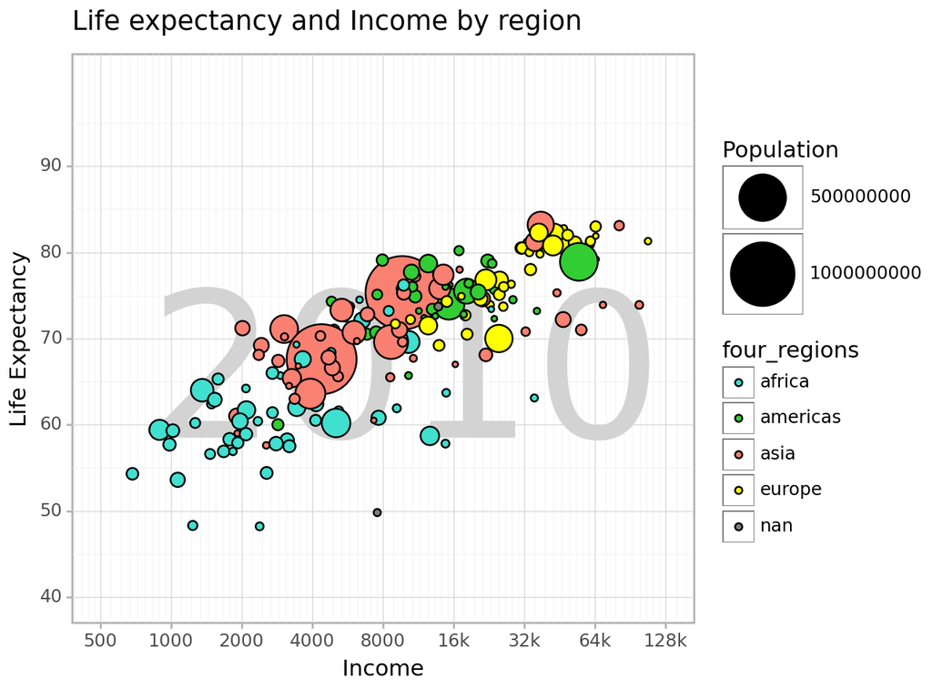

```python
#Part 3 to plot using plotline
Income = [500, 1000, 2000, 4000, 8000, 16000, 32000, 64000, 128000]
Income_labels = ['500', '1000', '2000', '4000', '8000', '16k', '32k', '64k','128k']
Colors_by_region = {
    'asia': 'salmon',
    'americas': 'limegreen',
    'africa': 'turquoise',
    'europe': 'yellow'
    }
life_exp_plot = (
    ggplot(q1data, aes(x='income', y='life_exp', fill='four_regions', size='population')) +
    annotate("text", x=10000, y=65, label="2010", size='100', color='lightgray') +
    geom_point() +
    scale_size_continuous(range=[1, 20]) +
    scale_fill_manual(values=Colors_by_region) +
    scale_y_continuous(limits=[40, 100], breaks=range(0, 100, 10)) +
    theme_light() +
    labs(title='Life expectancy and Income by region', x='Income', y='Life Expectancy', color='Region', size='Population') +
    scale_x_log10(breaks=Income, labels=Income_labels, limits=[500, 128000])
)

print(life_exp_plot)
```

**Part 4**

It also gives the median life expectancy with the upper and lower quartiles.

But, this graph does not help us in understanding the density of population from each region based on their income and life expectancy.

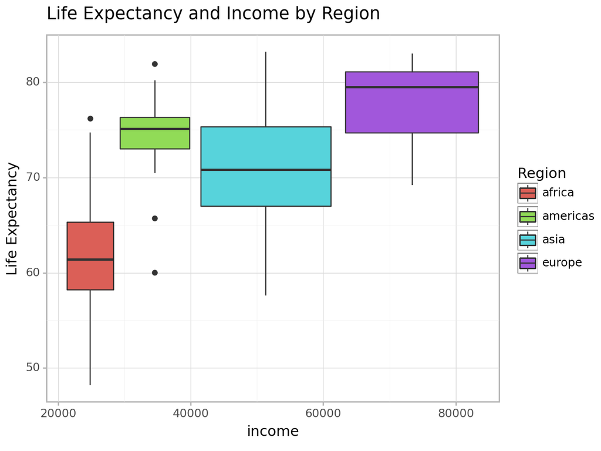

```python
# Got the remarks "/usr/local/lib/python3.10/dist-packages/plotnine/layer.py:284: PlotnineWarning: stat_boxplot : Removed 2 rows containing non-finite values."
# and it made a boxplot for the nan value, to avoind that we can use the drop command and then plot the graph
q1data = q1data.dropna()
Boxplot = (
    ggplot(q1data,
           aes(
              x='income',
              y='life_exp',
              fill='four_regions'
              )
           ) +
    geom_boxplot() +
    theme_light() +
    labs(
        title='Life Expectancy and Income by Region',
        x='income',
        y='Life Expectancy',
        fill='Region'
    )
)
print(Boxplot)
```

**Task 2**

Below is another plot of a visualization in Gapminder. Look it over and take note of the variables being visualized.

1. Identify, and list here, what aesthetics are being used and which variables are being mapped to each aesthetic.
2. Import the q2data.csv dataset.
3. Recreate the plot as best you can using plotnine.
4. What other geometries could you use here besides geom_point? Provide an actual plot of another geometry being used here and why it’s good or bad for visualizing these data.

**Part 1.** - Aesthetics used

```python
#Part 2 to Import the q2data.csv
q2data = pd.read_csv("q2data.csv")
q2data = q2data.dropna()
q2data
```

|  | imports | exports | energy | year | country | four_regions | six_regions | eight_regions | world_bank_region |
| --- | --- | --- | --- | --- | --- | --- | --- | --- | --- |
| 1 | 36.7 | 11.5 | 427 | 1997 | Albania | europe | europe_central_asia | europe_east | Europe & Central Asia |
| 2 | 22.5 | 22.6 | 825 | 1997 | Algeria | africa | middle_east_north_africa | africa_north | Middle East & North Africa |
| 6 | 12.9 | 10.4 | 1660 | 1997 | Argentina | americas | america | america_south | Latin America & Caribbean |
| 7 | 52.8 | 19.0 | 610 | 1997 | Armenia | europe | europe_central_asia | europe_east | Europe & Central Asia |
| 9 | 20.5 | 19.6 | 5550 | 1997 | Australia | asia | east_asia_pacific | east_asia_pacific | East Asia & Pacific |
| ... | ... | ... | ... | ... | ... | ... | ... | ... | ... |
| 198 | 22.9 | 22.6 | 2080 | 1997 | Uzbekistan | asia | europe_central_asia | asia_west | Europe & Central Asia |
| 200 | 22.7 | 20.9 | 2250 | 1997 | Venezuela | americas | america | america_south | Latin America & Caribbean |
| 201 | 52.2 | 44.8 | 340 | 1997 | Vietnam | asia | east_asia_pacific | east_asia_pacific | East Asia & Pacific |
| 204 | 31.6 | 24.6 | 617 | 1997 | Zambia | africa | sub_saharan_africa | africa_sub_saharan | Sub-Saharan Africa |
| 205 | 45.1 | 43.4 | 845 | 1997 | Zimbabwe | africa | sub_saharan_africa | africa_sub_saharan | Sub-Saharan Africa |

127 rows × 9 columns

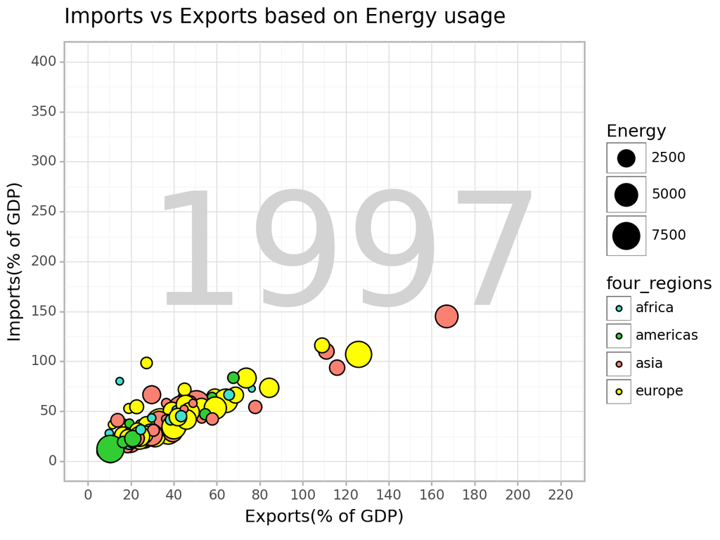

```python
#Part 3 to plot using plotline
# Preprocessing the data by converting the 'energy' column to numeric
q2data['energy'] = pd.to_numeric(q2data['energy'], errors='coerce')
# Drop rows where energy values are missing.
q2data = q2data[q2data['energy'].notna()]


imports_vs_exports_plot = (
    ggplot(q2data, aes(x='exports', y='imports', fill='four_regions', size='energy')) +
    annotate("text", x=120, y=200, label="1997", size='100', color='lightgray') +
    geom_point() +
    scale_size_continuous(range=[1, 10]) +
    scale_fill_manual(values=Colors_by_region) +  # Updated color mapping
    scale_x_continuous(limits=[0, 220], breaks=range(0, 221, 20)) +
    scale_y_continuous(limits=[0, 400], breaks=range(0, 401, 50)) +
    theme_light() +
    labs(
        title='Imports vs Exports based on Energy usage',
        x='Exports(% of GDP)',
        y='Imports(% of GDP)',
        color='Region',
        size='Energy'
    )
)

print(imports_vs_exports_plot)
```

**Part - 4**

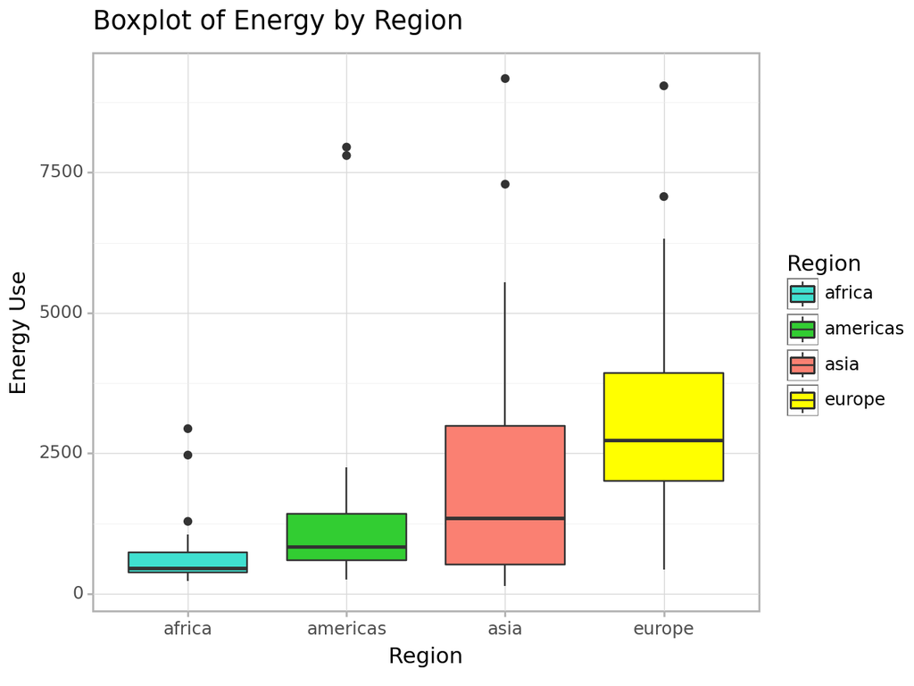

```python
# Creating the boxplot
Boxplot = (
    ggplot(q2data, aes(x='four_regions', y='energy', fill='four_regions')) +
    geom_boxplot() +
    scale_fill_manual(values=Colors_by_region) +
    theme_light() +
    labs(
        title='Boxplot of Energy by Region',
        x='Region',
        y='Energy Use',
        fill='Region'
    )
)

# Printing the plot
print(Boxplot)
```

**Task 3**

Below is a final plot of a visualization in Gapminder. Look it over and take note of the variables being visualized.

1. Identify, and list here, what aesthetics are being used and which variables are being mapped to each aesthetic.
2. Import the q3data.csv dataset.
3. Recreate the plot as best you can using plotnine.
4. What other geometries could you use here besides geom_point? Provide an actual plot of another geometry being used here and why it’s good or bad for visualizing these data.

**Part 1.** - Aesthetics used

X- Axis - *Individuals using internet*

Y- Axis - *GDP/capita*

```python
#Part 2 to Import the q3data.csv
q3data = pd.read_csv("q3data.csv")
q3data = q3data.dropna()
q3data
```

|  | internet_users | gdp | income | year | country | four_regions | six_regions | eight_regions | world_bank_region |
| --- | --- | --- | --- | --- | --- | --- | --- | --- | --- |
| 0 | 0.00456 | 330.0 | 1190.0 | 2001 | Afghanistan | asia | south_asia | asia_west | South Asia |
| 1 | 0.39000 | 2570.0 | 6780.0 | 2001 | Albania | europe | europe_central_asia | europe_east | Europe & Central Asia |
| 2 | 1.59000 | 3770.0 | 9230.0 | 2001 | Algeria | africa | middle_east_north_africa | africa_north | Middle East & North Africa |
| 4 | 11.30000 | 42600.0 | 35600.0 | 2001 | Andorra | europe | europe_central_asia | europe_west | Europe & Central Asia |
| 5 | 0.27000 | 2440.0 | 2900.0 | 2001 | Angola | africa | sub_saharan_africa | africa_sub_saharan | Sub-Saharan Africa |
| ... | ... | ... | ... | ... | ... | ... | ... | ... | ... |
| 209 | 4.91000 | 10800.0 | 14800.0 | 2001 | Venezuela | americas | america | america_south | Latin America & Caribbean |
| 210 | 1.85000 | 847.0 | 3270.0 | 2001 | Vietnam | asia | east_asia_pacific | east_asia_pacific | East Asia & Pacific |
| 212 | 0.51900 | 1190.0 | 4940.0 | 2001 | Yemen | asia | middle_east_north_africa | asia_west | Middle East & North Africa |
| 213 | 0.47800 | 991.0 | 2080.0 | 2001 | Zambia | africa | sub_saharan_africa | africa_sub_saharan | Sub-Saharan Africa |
| 214 | 1.10000 | 1330.0 | 3190.0 | 2001 | Zimbabwe | africa | sub_saharan_africa | africa_sub_saharan | Sub-Saharan Africa |

181 rows × 9 columns

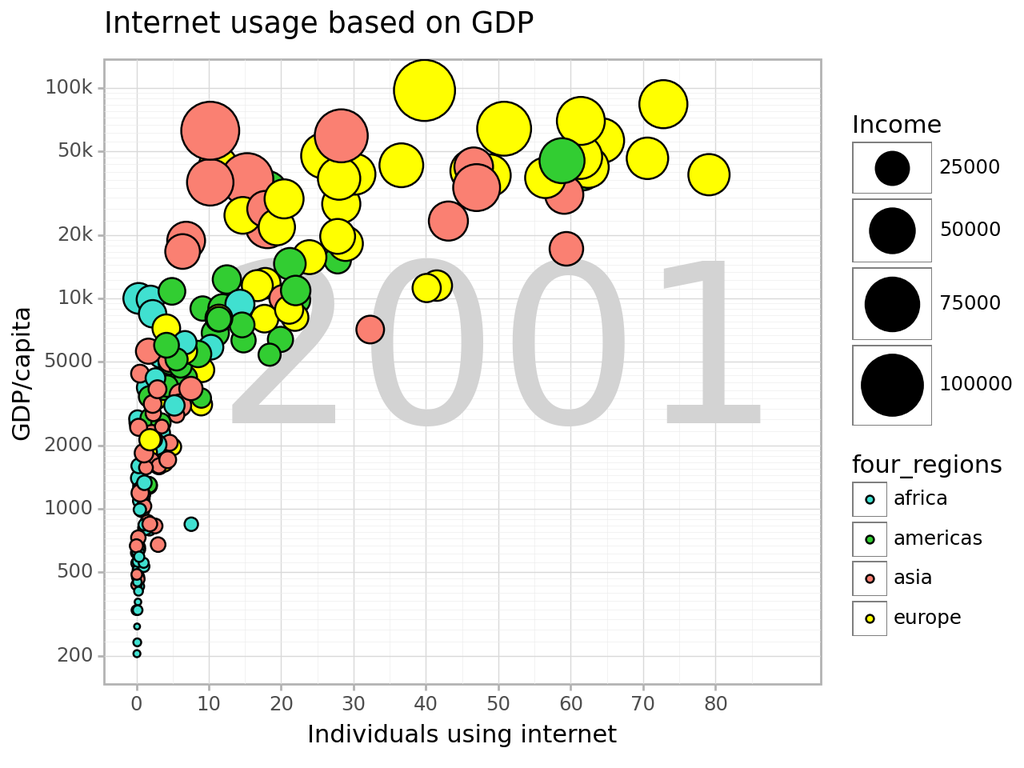

```python
#Part 3 to plot using plotline
# Remove rows with missing values
# q3data = q3data.dropna(subset=['internet_users', 'gdp', 'income', 'four_regions'])
# q3data = q3data[q3data['internet_users'].notna()]

breaks_values = [200, 500, 1000, 2000, 5000, 10000, 20000, 50000, 100000]
labels_values = ['200', '500', '1000', '2000', '5000', '10k', '20k', '50k', '100k']
#colors can be taken from previous code, as we have the same country names
# Creating the plot
internet_usage_plot = (
    ggplot(q3data, aes(x='internet_users', y='gdp', fill='four_regions', size='income')) +
    annotate("text", x=50, y=5000, label="2001", size='100', color='lightgray') +
    geom_point() +
    scale_size_continuous(range=[1, 15]) +
    scale_fill_manual(values=Colors_by_region) +  # Updated color mapping
    scale_x_continuous(limits=[0, 90], breaks=range(0, 90, 10)) +
    scale_y_log10(breaks=breaks_values, labels=labels_values, limits=[200, 100000]) +
    theme_light() +
    labs(title='Internet usage based on GDP', x='Individuals using internet', y='GDP/capita', color='Region', size='Income')
)

print(internet_usage_plot)
```

**Part - 4**

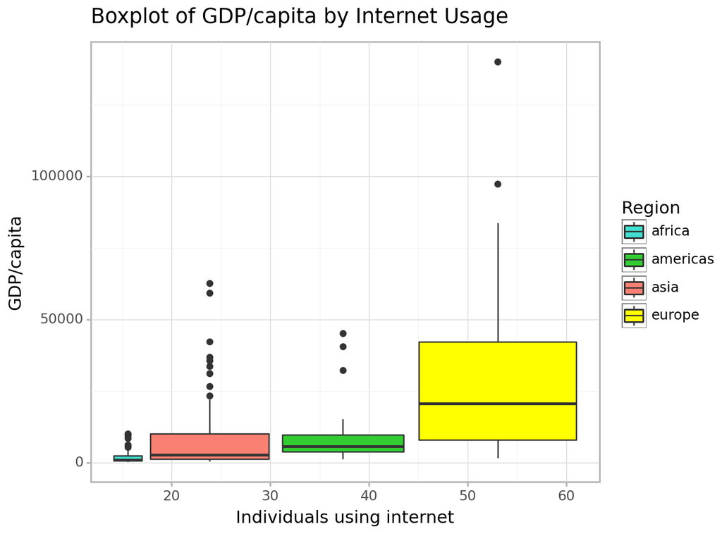

```python
Boxplot = (
    ggplot(q3data, aes(x='internet_users', y='gdp', fill='four_regions', size='income')) +
    geom_boxplot() +
    scale_fill_manual(values=Colors_by_region) +
    theme_light() +
    labs(
        title='Boxplot of GDP/capita by Internet Usage',
        x='Individuals using internet',
        y='GDP/capita',
        fill='Region',
        size='Income'
    )
)

print(Boxplot)
```